# IP Week 12

# Exploratory Data Analysis

## Univariate Analysis

### Counts

```r
# Checking the counts of those who clicked on ads
library(plyr)
count(ad$Clicked.on.Ad)
```

```
##   x freq
## 1 0  500
## 2 1  500
```

```r
# Checking the counts of Males in the Datasets
count(ad$Male)
```

```
##   x freq
## 1 0  519
## 2 1  481
```

```r
# Checking the counts of the countries
count(ad$Country)
```

```
##                                                       x freq
## 1                                           Afghanistan    8
## 2                                               Albania    7
## 3                                               Algeria    6
## 4                                        American Samoa    5
## 5                                               Andorra    2
## 6                                                Angola    4
## 7                                              Anguilla    6
## 8          Antarctica (the territory South of 60 deg S)    3
## 9                                   Antigua and Barbuda    5
## 10                                            Argentina    2
## 11                                              Armenia    3
## 12                                                Aruba    1
## 13                                            Australia    8
## 14                                              Austria    5
```

[output cut: 223 more lines]

```r
a = count(ad$Age)
a
```

```
##     x freq
## 1  19    6
## 2  20    6
## 3  21    6
## 4  22   13
## 5  23   19
## 6  24   21
## 7  25   27
## 8  26   37
## 9  27   33
## 10 28   48
## 11 29   48
## 12 30   39
## 13 31   60
## 14 32   38
```

[output cut: 29 more lines]

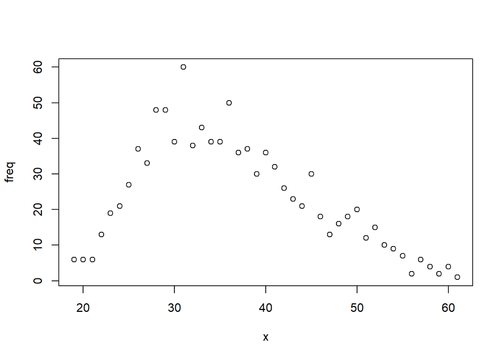

```r
plot(a)
```

### Mean

```r
mean(ad$Daily.Time.Spent.on.Site)
```

```
## [1] 65.0002
```

```r
mean(ad$Age)
```

```
## [1] 36.009
```

```r
mean(ad$Area.Income)
```

```
## [1] 55000
```

```r
mean(ad$Daily.Internet.Usage)
```

```
## [1] 180.0001
```

From the analysis the means of Daily time spent, Age, Area income and Daily internet usage are 65.0002, 36.009, 55000, and 180.0001 respectively.

### Median

```r
median(ad$Daily.Time.Spent.on.Site)
```

```
## [1] 68.215
```

```r
median(ad$Age)
```

```
## [1] 35
```

```r
median(ad$Area.Income)
```

```
## [1] 57012.3
```

```r
median(ad$Daily.Internet.Usage)
```

```
## [1] 183.13
```

From the analysis the medians of Daily time spent, Age, Area income and Daily internet usage are 68.215, 35, 57012.3, and 183.13 respectively.

### Mode

```r
getmode <- function(v) {
   uniqv <- unique(v)
   uniqv[which.max(tabulate(match(v, uniqv)))]
}
```

```r
getmode(ad$Daily.Time.Spent.on.Site)
```

```
## [1] 62.26
```

```r
getmode(ad$Age)
```

```
## [1] 31
```

```r
getmode(ad$Area.Income)
```

```
## [1] 61833.9
```

```r
getmode(ad$Daily.Internet.Usage)
```

```
## [1] 167.22
```

From the analysis the modes of Daily time spent, Age, Area income and Daily internet usage are 62.26, 31, 61833.9, and 167.22 respectively.

### Maximum

```r
max(ad$Daily.Time.Spent.on.Site)
```

```
## [1] 91.43
```

```r
max(ad$Age)
```

```
## [1] 61
```

```r
max(ad$Area.Income)
```

```
## [1] 79484.8
```

```r
max(ad$Daily.Internet.Usage)
```

```
## [1] 269.96
```

From the analysis the maximum values of Daily time spent, Age, Area income and Daily internet usage are 91.43, 61, 79484.8, and 269.96 respectively.

### Minimum

```r
min(ad$Daily.Time.Spent.on.Site)
```

```
## [1] 32.6
```

```r
min(ad$Age)
```

```
## [1] 19
```

```r
min(ad$Area.Income)
```

```
## [1] 13996.5
```

```r
min(ad$Daily.Internet.Usage)
```

```
## [1] 104.78
```

From the analysis the minimum values of Daily time spent, Age, Area income and Daily internet usage are 32.6, 19, 13996.5, and 104.78 respectively.

### Range

```r
range(ad$Daily.Time.Spent.on.Site)
```

```
## [1] 32.60 91.43
```

```r
range(ad$Age)
```

```
## [1] 19 61
```

```r
range(ad$Area.Income)
```

```
## [1] 13996.5 79484.8
```

```r
range(ad$Daily.Internet.Usage)
```

```
## [1] 104.78 269.96
```

### Quantile

```r
quantile(ad$Daily.Time.Spent.on.Site)
```

```
##      0%     25%     50%     75%    100%
## 32.6000 51.3600 68.2150 78.5475 91.4300
```

```r
quantile(ad$Age)
```

```
##   0%  25%  50%  75% 100%
##   19   29   35   42   61
```

```r
quantile(ad$Area.Income)
```

```
##       0%      25%      50%      75%     100%
## 13996.50 47031.80 57012.30 65470.64 79484.80
```

```r
quantile(ad$Daily.Internet.Usage)
```

```
##       0%      25%      50%      75%     100%
## 104.7800 138.8300 183.1300 218.7925 269.9600
```

### Interquantile Range

```r
IQR(ad$Daily.Time.Spent.on.Site)
```

```
## [1] 27.1875
```

```r
IQR(ad$Age)
```

```
## [1] 13
```

```r
IQR(ad$Area.Income)
```

```
## [1] 18438.83
```

```r
IQR(ad$Daily.Internet.Usage)
```

```
## [1] 79.9625
```

From the analysis the interquantile ranges of Daily time spent, Age, Area income and Daily internet usage are 27.1875, 13, 18438.83, and 79.9625 respectively.

### Variance

```r
var(ad$Daily.Time.Spent.on.Site)
```

```
## [1] 251.3371
```

```r
var(ad$Age)
```

```
## [1] 77.18611
```

```r
var(ad$Area.Income)
```

```
## [1] 179952406
```

```r
var(ad$Daily.Internet.Usage)
```

```
## [1] 1927.415
```

From the analysis the variances of Daily time spent, Age, Area income and Daily internet usage are 251.3371, 77.18611, 179952406, and 1927.415 respectively.

### Standard Deviation

```r
sd(ad$Daily.Time.Spent.on.Site)
```

```
## [1] 15.85361
```

```r
sd(ad$Age)
```

```
## [1] 8.785562
```

```r
sd(ad$Area.Income)
```

```
## [1] 13414.63
```

```r
sd(ad$Daily.Internet.Usage)
```

```
## [1] 43.90234
```

From the analysis the standard deviations of Daily time spent, Age, Area income and Daily internet usage are 15.85361, 8.785562, 13414.63, and 43.90234 respectively.

### Skewness

```r
library(e1071)
skewness(ad$Daily.Time.Spent.on.Site)
```

```
## [1] -0.370646
```

Daily time spent is fairly skewed.

```r
skewness(ad$Age)
```

```
## [1] 0.4777052
```

Age is fairly skewed.

```r
skewness(ad$Area.Income)
```

```
## [1] -0.6484229
```

Area income is moderately skewed to the left.

```r
skewness(ad$Daily.Internet.Usage)
```

```
## [1] -0.03343681
```

### Kurtosis

```r
kurtosis(ad$Daily.Time.Spent.on.Site)
```

```
## [1] -1.099864
```

The Daily time spent column has a platykurtic kurtosis.

```r
kurtosis(ad$Age)
```

```
## [1] -0.4097066
```

The Age column has a platykurtic kurtosis.

```r
kurtosis(ad$Area.Income)
```

```
## [1] -0.1110924
```

The Area income column has a platykurtic kurtosis.

```r
kurtosis(ad$Daily.Internet.Usage)
```

```
## [1] -1.275752
```

The Daily internet usage column has a platykurtic kurtosis.

### Histogram

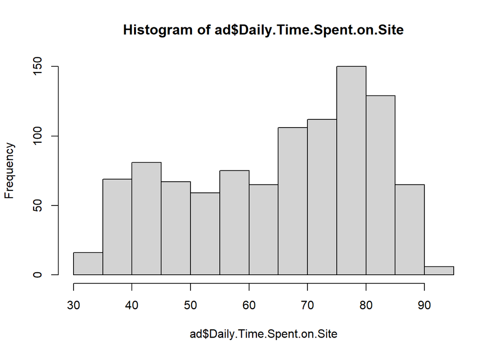

```r
hist(ad$Daily.Time.Spent.on.Site)
```

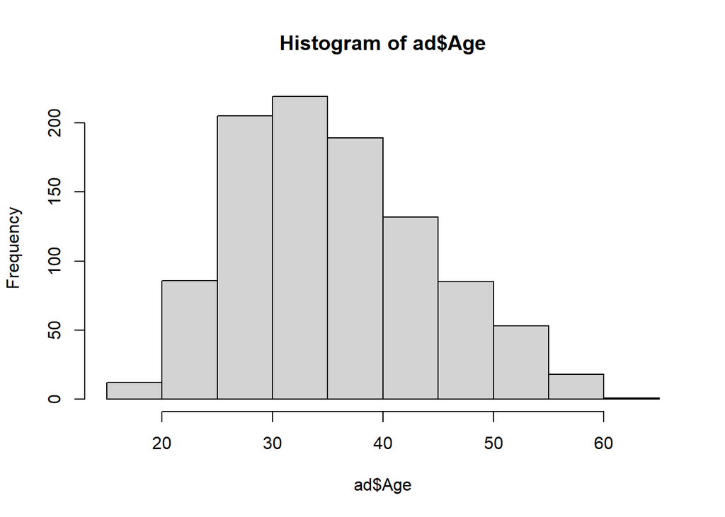

```r
hist(ad$Age)
```

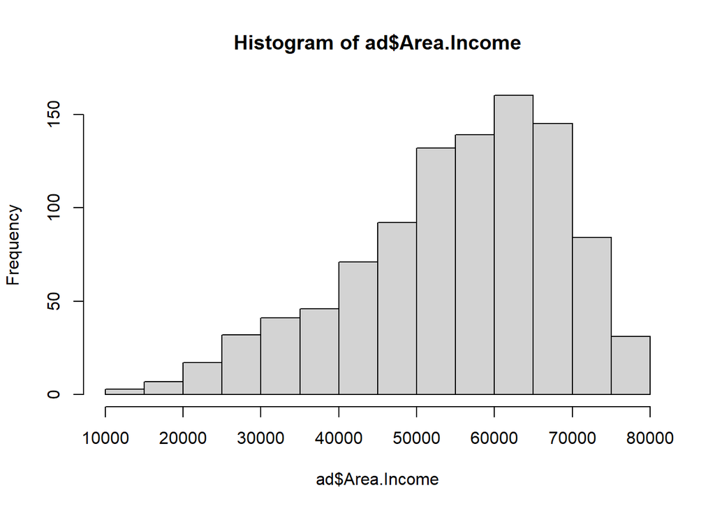

```r
hist(ad$Area.Income)
```

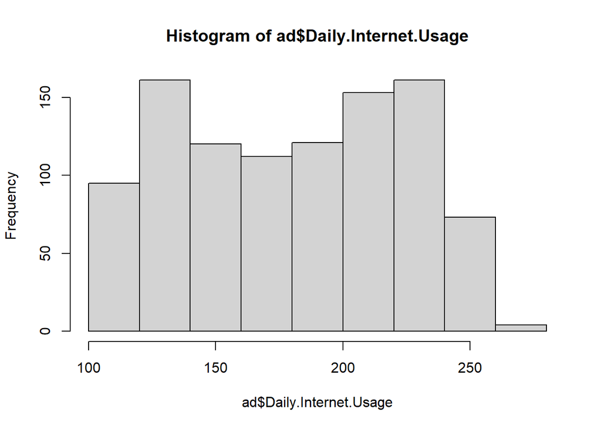

```r
hist(ad$Daily.Internet.Usage)
```

## Bivariate Analysis

```r
ad2 = subset(ad, select = c(Daily.Time.Spent.on.Site, Age, Area.Income, Daily.Internet.Usage))

head(ad2)
```

```
##   Daily.Time.Spent.on.Site Age Area.Income Daily.Internet.Usage
## 1                    68.95  35    61833.90               256.09
## 2                    80.23  31    68441.85               193.77
## 3                    69.47  26    59785.94               236.50
## 4                    74.15  29    54806.18               245.89
## 5                    68.37  35    73889.99               225.58
## 6                    59.99  23    59761.56               226.74
```

### Covariance

```r
# Finding the covariance of the variables
cov(ad2)
```

```
##                          Daily.Time.Spent.on.Site          Age  Area.Income
## Daily.Time.Spent.on.Site                251.33709    -46.17415     66130.81
## Age                                     -46.17415     77.18611    -21520.93
## Area.Income                           66130.81091 -21520.92580 179952405.95
## Daily.Internet.Usage                    360.99188   -141.63482    198762.53
##                          Daily.Internet.Usage
## Daily.Time.Spent.on.Site             360.9919
## Age                                 -141.6348
## Area.Income                       198762.5315
## Daily.Internet.Usage                1927.4154
```

From the analysis Daily time spent and Area income, Daily time spent and Daily internet usage, Area income and Daily internet usage all have positive covariances between them hence have a positive linear relationship. From the analysis Daily time spent and Age, Age and Area income, Age and Daily internet usage all have negative covariance between them hence have a negative linear relationship.

### Correlation

```r
# Finding the correlation coefficients of
cor(ad2)
```

```
##                          Daily.Time.Spent.on.Site        Age Area.Income
## Daily.Time.Spent.on.Site                1.0000000 -0.3315133   0.3109544
## Age                                    -0.3315133  1.0000000  -0.1826050
## Area.Income                             0.3109544 -0.1826050   1.0000000
## Daily.Internet.Usage                    0.5186585 -0.3672086   0.3374955
##                          Daily.Internet.Usage
## Daily.Time.Spent.on.Site            0.5186585
## Age                                -0.3672086
## Area.Income                         0.3374955
## Daily.Internet.Usage                1.0000000
```

### Correlation Matrix

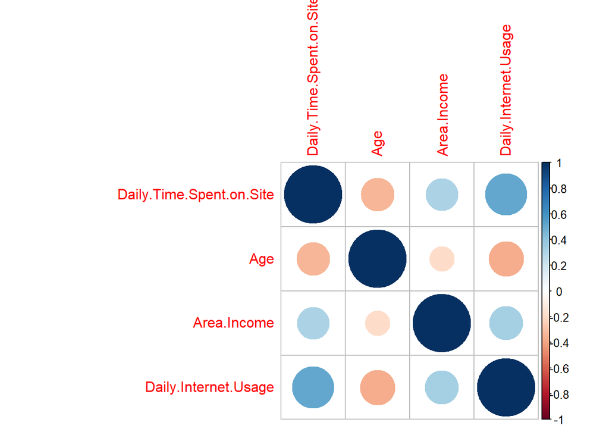

```r
#Creating a correlation matrix
library('corrplot')
corrplot(cor(ad2))
```

From the correlation and correlation matrix output it shows Daily time spent and Daily internet usage have a moderate positive correlation to each other. Age and Daily internet usage have a moderate negative correlation to each other.

### Scatter Plots

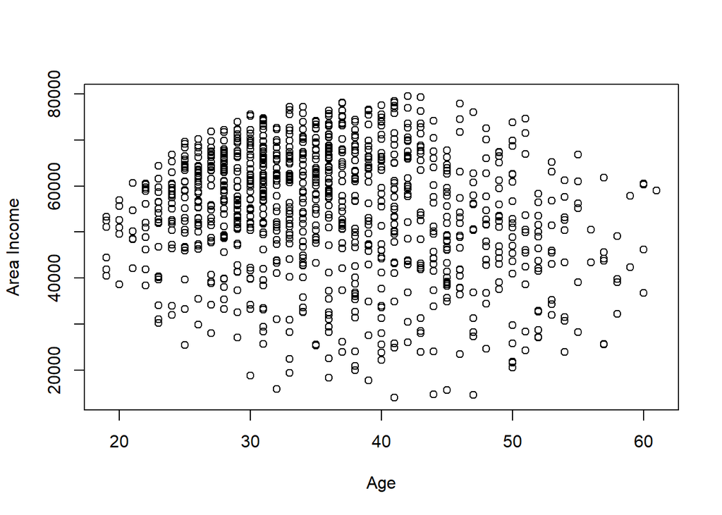

```r
# Plotting a scatterplot between Age and Area income
plot(ad$Age, ad$Area.Income, xlab="Age", ylab="Area Income")
```

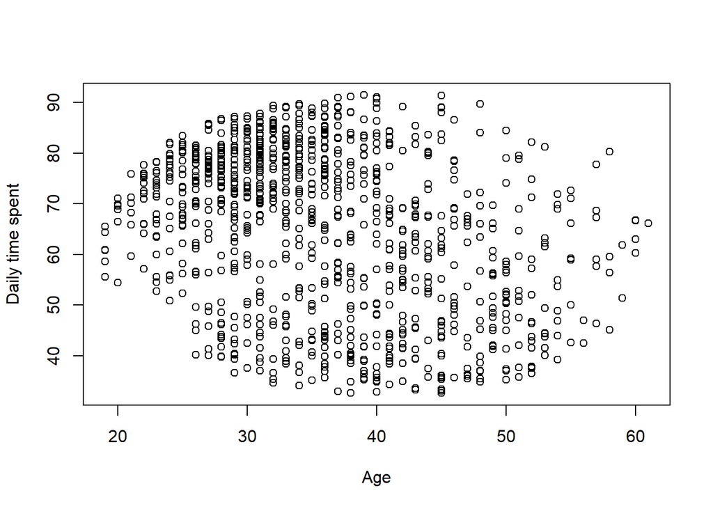

```r
# Plotting a scatterplot between Age and Daily time spent
plot(ad$Age, ad$Daily.Time.Spent.on.Site, xlab="Age", ylab="Daily time spent")
```

The scatter plot between Age and Daily time spent shows a negative relationship between the two.

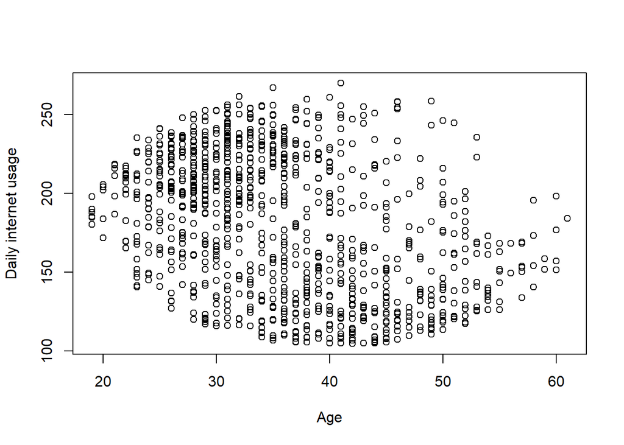

```r
# Plotting a scatterplot between Age and Daily internet usage
plot(ad$Age, ad$Daily.Internet.Usage, xlab="Age", ylab="Daily internet usage")
```

The scatter plot between Age and Daily internet usage shows a negative relationship between the two.

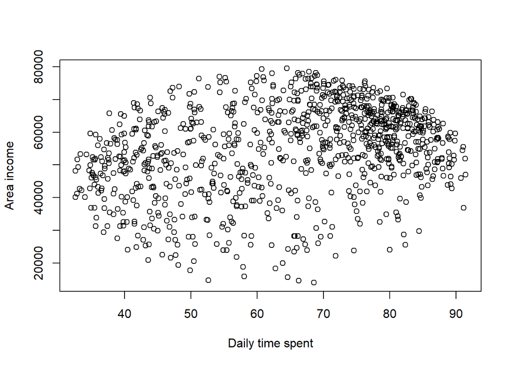

```r
# Plotting a scatterplot between Daily time spent and Area income
plot(ad$Daily.Time.Spent.on.Site, ad$Area.Income, xlab="Daily time spent", ylab="Area income")
```

The scatter plot between Daily time spent and Area income shows a positive relationship between the two.

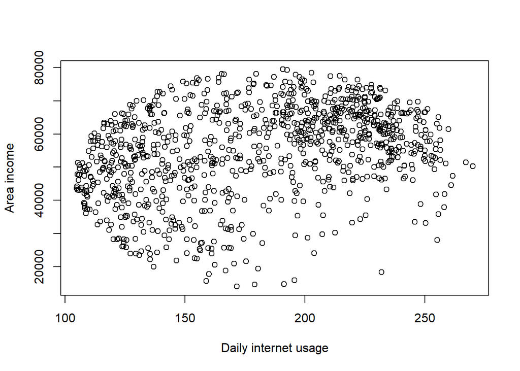

```r
# Plotting a scatterplot between Daily internet usage and Area income
plot(ad$Daily.Internet.Usage, ad$Area.Income, xlab="Daily internet usage", ylab="Area income")
```

The scatter plot between Area income and Daily internet usage shows a positive relationship between the two.

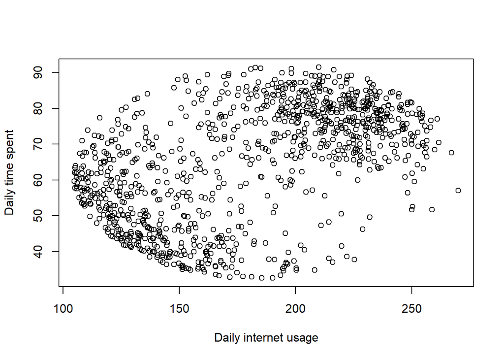

```r
# Plotting a scatterplot between Daily internet usage and Daily time spent
plot(ad$Daily.Internet.Usage, ad$Daily.Time.Spent.on.Site, xlab="Daily internet usage", ylab="Daily time spent")
```

The scatter plot between Daily internet usage and Daily time spent shows a positive relationship between the two.

# Challenging the Solution

The solution can be challenged by performing Logistic regression to enable the client to predict on which people are likely to click the advert about her business.

# Recommendations